# Casos de Covid-19 em Bauru-SP: Trabalho Final

Christian Rodrigues Batista

13/03/2022

## 1. Visão Geral

Este relatório representa a análise inicial e exploratória sobre como a pandemia de Coronavirus (Covid-19) afeta a cidade de Bauru - São Paulo, Brasil.

Devido a relevância que possui na região Centro Oeste de São Paulo, a cidade de Bauru foi a escolhida para o desenvolvimento deste relatório de pesquisa em Data Science sobre o impacto da pandemia do novo Coronavirus (Covid-19).

Os dados coletados foram publicados no jornal local usando dados do sistema municipal de saúde.

## 2. Análise Exploratória dos Dados

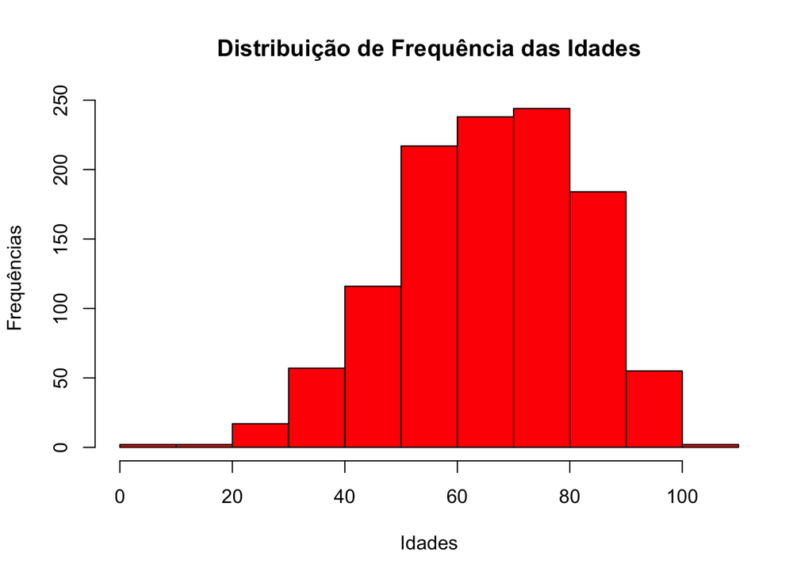

Já na figura 2, apresentamos um grafico de barras que contem as médias aritméticas de dias que correspondem a permanencia hospitalar em seus dois tipos de hospedagem, pública e privada, visando que as data que correspondem o périodo de permanencia são a data de inicio dos sintomas e data de óbito.

```
## [1] "Dados da Hospedagem Pública (Dias de Permanênica)"
```

[output not shown]

[output cut: 20 more lines]

```
## [1] "Dados da Hospedagem Privada (Dias de Permanênica)"
```

[output not shown]

```
## [1] "Média de dias de permanência em Hospedagem Pública:  20.8587848932677"
```

```
## [1] "Média de dias de permanência em Hospedagem Privada:  19.9840255591054"
```

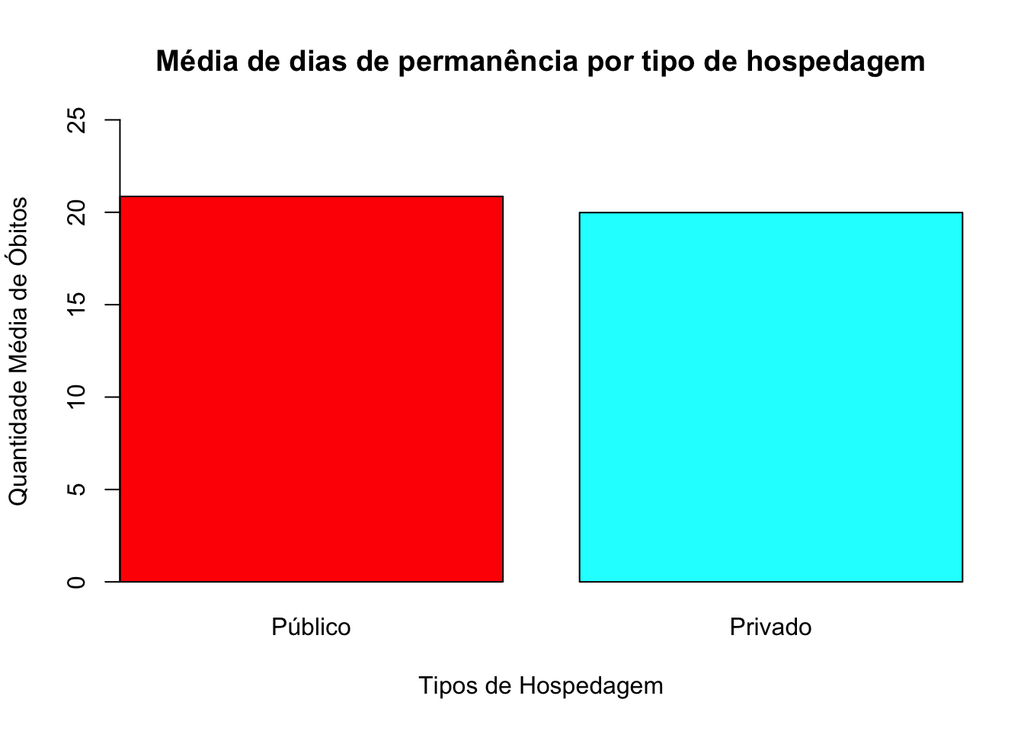

Na figura 3, temos como escolha um gráfico de barras comparativo, nele é apresentado um numero total de óbitos no periodo de 2020 a 2022, segundo os boletins emitidos pela prefeitura da cidade, e outras duas barras, que apresentam a quantidade de óbitos de pessoas não vacinadas e pessoas vacinadas.

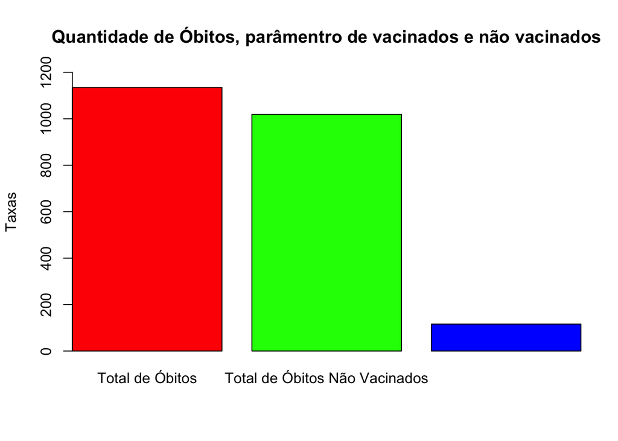

Já na figura 4, temos uma relação das caracteristicas das comorbidades que podem ter complicado o quadro clinico dos paciêntes que contrairam o Covid19. Em um gráfico de barras podemos ter o paramentro do total de pessoas que possuia algum tipo de comorbidades, e ao lado as colunas que apresentam a quantiadade de pessoas que contiam algum tipo de comorbidade separadas nas seguintes categorias escolhidas: Asma, Obesidade, Cardiopatia, Diabetes, Pneumonia, Hipertensão, Câncer, AVC, Problemas Cardiovascular e Doenças Crônicas. É importante notar que o mesmo paciênte pode ou não conter mais de uma comorbidade de forma simultânea.

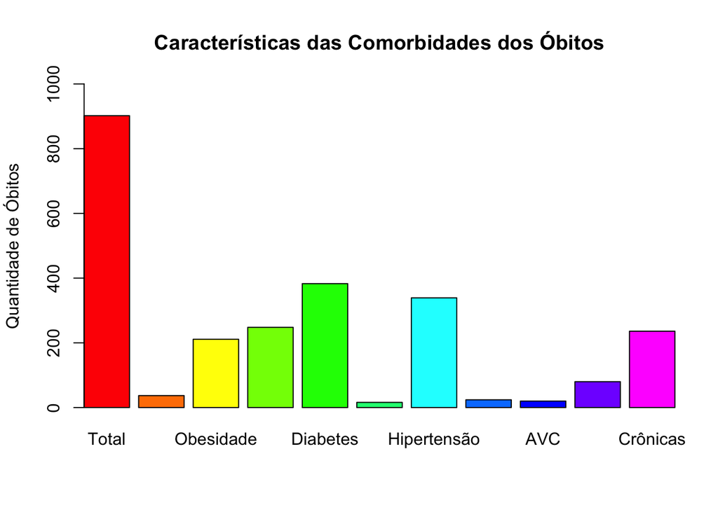

Na última imagem, figura 5, apresentamos avanço dos óbitos de paciência que contrairam o novo coronavírus nos períodos mais críticos da pandemia, de 2020 a 2022.

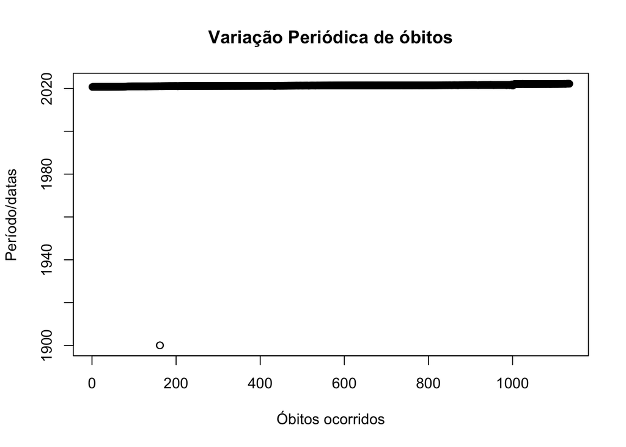